# [2019]_Горелов_Шарпей_II

# СОВРЕМЕННЫЕ ТЕХНОЛОГИИ ПРОГРАММИРОВАНИЯ: РАЗРАБОТКА WINDOWS-ПРИЛОЖЕНИЙ НА ЯЗЫКЕ С#

$$Том 2$$

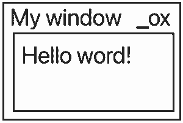

Страница 000

С. В. ГОРЕЛОВ

СОВРЕМЕННЫЕ ТЕХНОЛОГИИ ПРОГРАММИРОВАНИЯ: РАЗРАБОТКА WINDOWS-ПРИЛОЖЕНИЙ НА ЯЗЫКЕ С#

Учебник для студентов, обучающихся по дисциплине «Современные технологии программирования», направление «Прикладная информатика» (09.03.03 — для бакалавров, 09.03.04 — для магистров).

В двух томах. Однако. Чукча не читатель, чукча — писатель.

# Том-таки, слава богу, второй.

Москва 2019

Под научной редакцией доктора экономических наук Лукьянова Павла Борисовича.

УДК 004(075.8) ББК 32.973.26-018.1 Г68

Страница 001

Автор:  
**Серкей Витальевич Горелов** - кандидат технических наук, лоцент Департамента анализа данных, принятия решений и финансовых технологий Финансового университета при Правительстве Российской Федерации.  
Рецензенты:  
**Завгородний В.И.** — доктор экономических наук, профессор Финансового университета при Правительстве Российской Федерации;  
**Волков А.Г.** — кандидат технических наук, доцент, начальник кафедры Военной академии РВСН им. Петра Великого.  
Г 68 Горелов С.В.  
Современные технологии программирования: разработка Windows-приложений на языке С#: учебник: в 2 т. Т. ІІ / С.В. Горелов; под науч. ред. П.Б. Лукьянова. — М.: Прометей. 2019. — 378 с.

Страниц 2

# СОДЕРЖАНИЕ

- Страница 7 - Предисловие.
- Страница 10 - 1. Способы табличного отображения данных
- Cтраница 13 - 2. DataGridView: режим привязки
  - Cтраница 13 - 2.1. Общие сведения
  - Cтраница 14 - 2.2. Разработка приложения с DataGridView
  - Cтраница 19 - 2.3. Настройка таблицы в визуальном режиме
    - Cтраница 20 - Отображаемые свойства таблицы
    - Cтраница 32 - Отображаемые свойства столбца
    - Cтраница 37 - Стиль ячеек столбца
    - Cтраница 41 - Настройка ширины конкретного столбца......
- _
  - Cтраница 41 - 2.4. Архитектура DataGridView
    - Cтраница 41 - Особенности привязки DataGridView к данным
    - Cтраница 46 - Коллекции таблицы DataGridView
    - Cтраница 47 - Нумерация строк, столбцов и ячеек
    - Cтраница 48 - Особенности создания новой записи.
  - Cтраница 49 - 2.5. Работа с объектами DataGrid View
    - Cтраница 49 - Взаимосвязь основных классов таблицы
    - Cтраница 49 - Коллекция столбцов
    - Cтраница 52 - Коллекция строк
    - Cтраница 54 - Коллекция ячеек
    - Cтраница 58 - Выбранные строки, столбцы и'ячейки.
    - Cтраница 60 - Текущие строки и ячейки
    - Cтраница 62 - Угловой заголовок
- _
  - Cтраница 63 - 2.6. Стандартный интерфейс таблицы DataGridView
  - Cтраница 65 - 2.7. Проблемы редактирования ячеек
  - Cтраница 66 - 2.8. Проверка значений, введенных в ячейки
    - Cтраница 66 - Общие сведения.
    - Cтраница 67 - Проверки значения на уровне ячейки
    - Cтраница 74 - Индикация ошибки
    - Cтраница 75 - Проверка зничений на уровне строки
  - Cтраница 89 - 2.9. Форматирование значений
  - Cтраница 92 - 2.10. Добавление свободных столбнов
  - Cтраница 96 - 2.11. Программное манипулирование записями
  - Cтраница 107 - 2.12. Фильтрация строк таблицы

Страница 3

- _
  - Cтраница 111 - 2.13. Сортировка таблицы ...
  - Cтраница 114 - 2.14. Ячейки типа DataGridViewCheckBoxCell. .
  - Cтраница 118 - 2.15. Ввод в ячейки с помощью элементов управления.
  - Cтраница 121 - 2.16. Добавление столбца ComboBox
    - Cтраница 122 - Внутренний список объектов
    - Cтраница 125 - Внешний список объектов.
  - Cтраница 135 - 2.17. Полный текст программы . . . . •
  - Cтраница 174 - 2.18. Отображение дочерней таблицы. ...
  - Cтраница 178 - 2.19. Задания для самостоятельной работы .
- Cтраница 182 - 3. DataGridView: непривязанный режим
  - Cтраница 182 - 3.1. Создание таблицы.
  - Cтраница 184 - 3.2. Операции со столбцами
  - Cтраница 186 - 3.3. Операции со строками
  - Cтраница 187 - 3.4. Операции с ячейками
  - Cтраница 187 - 3.5. Виртуальный режим
  - Cтраница 192 - 3.6. Задания для самостоятельной работы
- Cтраница 195 - 4. Элемент управления TreeView
  - Cтраница 195 - 4.1. Общие сведения
    - Cтраница 195 - Структура элемента управления TreeView.
    - Cтраница 197 - Основные свойства TreeView
  - Cтраница 198 - 4.2. Работа с узлами
    - Cтраница 198 - Добавление узлов
    - Cтраница 201 - Удаление узлов
    - Cтраница 202 - Текущий узел
    - Cтраница 202 - Путь к выбранному узлу
    - Cтраница 203 - Доступ к произвольному узлу
- _
  - Cтраница 204 - 4.3. Динамическое построение Tree View
  - Cтраница 211 - 4.4. Пользовательские данные в Tree View
  - Cтраница 215 - 4.5. Рекурсивный обход TreeView ..
  - Cтраница 216 - 4.6. Определение значков для Tree View
  - Cтраница 217 - 4.7. Задания для самостоятельной работы ......
- Cтраница 219 - 5. Компонент ImageList
- Cтраница 221 - 6. Компонент ToolTip .
  - Cтраница 221 - 6.1. Вывод всплывающей подсказки .
  - Cтраница 223 - 6.2. Вывод сообщения об ошибке

СТРАНИЦА 4

- Cтраница 225 - 7. Элемент управления TabControl
  - Cтраница 225 - 7.1. Визуальный способ разработки. .
  - Cтраница 231 - 7.2. Подробнее о вкладках .
  - Cтраница 233 - 7.3. Задания для самостоятельной работы .
- Cтраница 234 - 8. Календари
  - Cтраница 234 - 8.1. Элемент управления MonthCalendar
  - Cтраница 238 - 8.2. Элемент управления DateTimePicker
- Cтраница 243 - 9. Элемент управления ProgressBar
  - Cтраница 243 - 9.1. Основные сведения
  - Cтраница 244 - 9.2. Стиль Marquee
  - Cтраница 246 - 9.3. Стиль Blocks
  - Cтраница 250 - 9.4. Стиль Continuous
  - Cтраница 251 - 9.5. Задания для самостоятельной работы
- Cтраница 252 - 10. Элемент управления TrackBar
  - Cтраница 252 - 10.1. Общие сведения
  - Cтраница 255 - 10.2. Задания для самостоятельной работы
- Cтраница 256 - 11. Разработка макета формы
  - Cтраница 257 - 11.1. Элемент управления SplitContainer
  - Cтраница 259 - 11.2. Элемент управления TableLayoutPanel
  - Cтраница 267 - 11.3. Элемент управления FlowLayoutPanel
- Cтраница 269 - 12. Сохранение параметров программы
  - Cтраница 270 - 12.1. Системная технология сохранения параметро
    - Cтраница 270 - Общие сведения
    - Cтраница 274 - Использование Visual Studio для создания параметров
    - Cтраница 297 - Сохранение списка строк элементов ComboBox и ListBox
    - Cтраница 302 - Создание параметров программы вручную
    - Cтраница 311 - Проверка параметров перед их сохранением
    - Cтраница 315 - Дополнительные сведения
  - Cтраница 317 - 12.2. Сохранение в файле с помощью Stream Writer
    - Cтраница 317 - Сохранение данных интерфейса в текстовом файле
    - Cтраница 320 - Загрузка данных из текстового файла
  - Cтраница 322 - 12.3. Использование системного реестра
    - Cтраница 322 - Сохранение значений
    - Cтраница 323 - Восстановление значений
    - Cтраница 324 - Очистка реестра
  - Cтраница 325 - 12.4. Внедрение данных в ехе-файл
  - Cтраница 334 - 12.5. Задания для самостоятельной работы

Страница 5

- Cтраница 335 - 13. Хранение данных в виде ресурсов
  - Cтраница 335 - 13.1. Понятие ресурса
    - Cтраница 335 - Типы ресурсов и их описание
    - Cтраница 337 - Resx-файл формы
    - Cтраница 338 - Resx-файл проекта
    - Cтраница 339 - Resx-файп разработчика
  - Cтраница 340 - 13.2. Членис ресурсов
  - Cтраница 341 - 13.3. Связывание и внедрение
  - Cтраница 342 - 13.4. Как извлечь из сборки внедренный файл
    - Cтраница 343 - Ивненение статуса ресурса
    - Cтраница 343 - Экспорт и импорт ресурса
- Cтраница 345 - 14. Разработка мультиязычных прижений
  - Cтраница 345 - 14.1. Основные сведения
    - Cтраница 346 - Плобализация и локализация
    - Cтраница 346 - Язык и региональные параметры
    - Cтраница 349 - Ресурсы формы и ресурсы разработчика
    - Cтраница 350 - Текущий поток и культуры
  - Cтраница 351 - 14.2. Пример создания мультиязычного приложения
    - Cтраница 352 - Мультиязычные ресурсы формы
    - Cтраница 356 - Мультиязычные ресурсы разработчика
    - Cтраница 364 - Локализация приложения
  - Cтраница 374 - 14.3. Задания для самостоятельной работы......
- Cтраница 375 - Заключение
- Cтраница 376 - Литература

Страница 6

# ПРЕДИСЛОВИЕ

Во втором томе учебника рассмотрена структурная и функциональная организация элемента управления `DataGridView`. Этот элемент отображает данные в табличном виде. Данные могут использоваться как из внешнего источника в режиме привязки, так и формироваться в программе в процессе её выполнения. Элемент управления `DataGridView` имеет богатую функциональность и состоит из множества классов. Одних только событий предоставляется более 180. Понятно, что описать все возможности этого элемента в рамках одного пособия не представляется возможным. Поэтому в данном учебнике показано, как можно использовать элемент управления `DataGridView` на примере приложения, последовательно разрабатываемого вместе с читателем. С решением очередной задачи программа становится все совершеннее и сложнее. В учебнике автор предпринял попытку решить большинство из тех задач, с которыми сталкиваются разработчики. Итогом такого подхода явилась готовая программа, которая может служить примером и основой для разработки других приложений.

Страница 7

Кроме элемента управления `DataGridView`, рассмотрено также несколько сложных элементов управления, например, `TreeView`, и ряд достаточно простых, но не так часто используемых, элементов. Все вместе они предоставляют возможности для разработки программ профессионального уровня. **В данном томе** рассмотрен ряд технологий, используемых для создания пользовательского интерфейса. К этим технологиям огносятся: **во первых**, сохранение и восстановление состояния элементов управления и формы; **во вторых**, использование ресурсов; **в третьих**, разработка мультиязычных приложений. Сохранение и восстановление состояния элементов управления и форм — это не часто используемая на практике технотогия. Однако приложения, которые должны быть разработаны на профессиональном уровне, дотжны использовать эту технологию. Тем более что весь процесе сохранения и восстановления параметров программы актоматизирован на достаточно высоком уровне.

Кроме техпологии, поддерживаемой средой разработки `Visual Studio`, рассматриваются способы: **во первых**, сохранения данных в текстовом файле с помошью потоковово ввода-вывода; **во вторых**, сохранения данных в реестре; **в третьих**, внедрение данных в текущий ехе-файл приложения. **Во всех перечисленных выше технологиях**, естественно, рассматривастся и процесс восстановления этих данных в приложении. **Технология разработки мультиязычных** приложений включаст решение вопросов глобализации и локализации приложений. Владение этой технологией, в первую очередь необходимо тем, кто планирует создавать программные продукты для внутреннего и внешнего рынков. **Изложенный материал опирается** на опыт автора, поэтому он допускает, что существуют какие-либо другие, может быть бопсе эффективные, способы решения задач. Тем не менсе, данный учебник в значительной степени облегчит разработчику создание качественных программ и подвигнет сго на более глубокое изуче ние материала. **Учебник** «Современные технологии программирования: разрабовка `Windows`-приложений на языке `С#`» написан в соотвевервии с учебным планом направления 09.03.03 «Прикладная информатика» и требованнями Федерального государственного образовавельного стандарта высшего образования последнего поколения. Учебник ориентирован на формирование профессиопальных компетевций, связанных с использованием теоретиче ских знаний и практических навыков при анализе и разработке программных систем с использованием объектно-ориентированного языка программирования и современных технологий.

Страница 8

В результате освоения дисциплины студенты должны: `знать`: **во первых**, назначение и свойства элементов управления и компонситов пользовательского интерфейел; **во вторых**, основные способы использования элементов управления и компонентов пользовательского интерфейса; **в третьех**, назначение и возможности интегрированной визуальной среды программирования; **в четвертых**, возможности современных технологий, внедряемых в профессиональные приложения с использованием интегрированной среды программирования; `уметь`: **во первых**, создавать эргономичный пользовательский интерфейс приложения; **во вторых**, использовать элементы управления и компоненты пользовательского интерфейса при разработке приложений; **в третьих**, использовать возможности интегрированной визуальной среды программирования; **в четвертых**, использовать современные технологии при разработке профессиональных приложений; **в пятых**, использовать средства языка программирования и визуальной среды для отладки программы; `владеть`: **во первых**, навыками проектирования пользовательского интерфейса с использованием элементов управления и компонентов; **во вторых**, навыками работы в интегрированной визуальной среде программирования при создании приложения; **в третьих**, навыками реализации современных технологий в разрабатываемых профессиональных приложениях.

Страница 9

# 1. СПОСОБЫ ТАБЛИЧНОГО ОТОБРАЖЕНИЯ ДАННЫХ

Страница 10

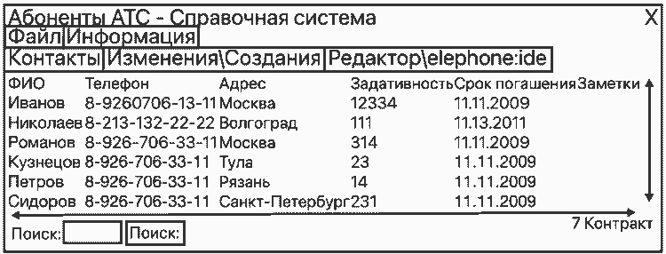

Рис. 1.1. Отображение данных в элементе управления `ListView`

Мы не будем изучать элемент `ListView`, так как его возможности в рассматриваемом контексте полностью перекрываются элементом управления `DataGridView`. Причем `DataGridView` не содержит недостатков элемента `ListView`. **Поскольку понятие** «таблица» в программировании в первую очерель относится к таблицам реляционной базы данных, то `DataGridView` часто называют сеткой. Тем не менее, в данном разделе для простоты мы будем называть `DataGridView` таблицей и только там, где речь будет идти о таблицах базы данных, будем переходить к термину «сетка». **Элемент управления** `DataGridView` является одним из самых мошных и сложных элементов управления. Он предназначен для отображения данных, хранящихся в самой таблице, или из внешнего источника данных: базы данных, XML-файла, веб-службы XML, коллекции объектов или другого источника данных. Информация отображается в традиционном формате — «строки-столбцы».

Страница 11

**В элемент управления** `DataGridView` данные могут быть загружены несколькими способами:

- 1. Таблицу `DataGridView` можно привязать к источнику данных. В этом случае столбцы будут созданы автоматически и в них отобразятся привязанные данные. Такие столбцы называются привязанными.
- 2. Таблицу `DataGridView` можно заполнить данными программным способом, не используя привязку. Разработчик должен тем или иным способом создать столбцы и строки с данными. Такие столбцы называются свободными и или не привязаными.
- 3. Таблица `DataGridView` может содержать как привязанные, так и свободные столбцы. Это комбинированный режим.
- 4. С целью экономии оперативной памяти для отображения данных в таблице `DataGridView` может быть использован так называемый виртуальный режим.

В данном томе учебника упор делается на разработку программ с использованием таблиц, привязанных к источнику данных. Другие режимы так же будут рассмотрены, но не так подробно.

Страница 12

# 2. DATAGRIDVIEW: РЕЖИМ ПРИВЯЗКИ

### 2.1. Общие сведения

Здесь и далее, до особых указаний, будем рассматривать первый способ, то есть отображение в таблице записей (объектов) из источника данных. Привязка таблицы к источнику данных значительно облегчает работу с таблицей. Для привязки используется компонент BindingSource (привязка рассмотрена в разделе 18 тома 1). **Особенность привязки состоит** в том, что данные из внешнего источника не хранятся в ячейках таблицы. Таблица хранит лишь ссылки на объекты источника данных. Ячейки служат для вызова метода `get` свойств источника данных с целью получения и отображения данных и вызова метода `set` для записи значений в источник. **Таблица `DataGridView`** обладает богатой базовой функциональностью, доступной по умолчанию с помощью её интерфейса. К таким функциям, в первую очередь, относятся: добавление новых строк, удаление одной или нескольких строк, изменение значений в ячейках. Кроме того, при помощи `DataGridView` можно настроить заголовки и ширину столбцов, внешний вид отдельных ячеек, зафиксировать строки и столбцы на своем месте при прокрутке таблицы, отображать элементы управления внутри ячеек, непользовать свободные столбцы наряду с привязанными, менять местами столбцы и г.д. Благодаря этому, сели не требуется выполнять специальную проверку и обработку табличных данных, использование в программе таблицы `DataGridView` потребует от разработчика минимум ручного программировання.

Страница 13

### 2.2. Разработка приложения c `DataGridView`

Для изучення разичных способов работы с `DataGridView` нам потребуется пример, поэтому на первом этапе разработаем простейшее приложение для отображения в `DataGridView` списка ктнентов отеля. Это приложение послужит основой для опиеания архитектуры и возможностей элемента управления `DataGridView`. **Начнем разработку приложения** е создання нового проекта `Windows Forms`. Добавим в проект класе `Client`, имеющий следующее определение:

```
public class Client
{
    public string Name { get; set; } // Фамилия клиента.
    public uint Room { get; set; } // Номер комнаты.
    public DateTime Date1 { get; set; } // Дата заезда.
    public DateTime Date2 < get; set; } // Дата отъезда.
```

Страница 14

```
    // Признак приоритетного клиента.
    public bool VIP { get; set; }
    public Client() // Текущие даты.
    {
        Date1 = DateTime Now.Date;
        Date2 = Date1;
    }
    // Конструктор по умолчанию
    public Client(string nm, uint rm, DateTime dt1, DateTime dt2, bool vip)
    {
        Name = nm;
        Room = rm;
        Date1 = dt1;
        Date2 = dt2;
        VIP = vip;
    }
}
```

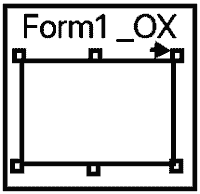

Рис. 2.1. Форма с таблицей до привязки к данным

В строке «Выберите источник данных» щелкнем на кнопку ↓ и в раскрывшемся окне выберем строку «Добавить источник данных проекта...». **Затем щелкнем значок** «Объект» и нажмем «Далее». В окне отобравится имя нашего проекта с маркером →. Раскрывая проект, а за см пространство имен. дойдем до класса `Client` и отметим его гасточкой (см. рис. 2.2). Если класс `Client` не отображается, значит. **Вы не построили решение**. Выполните построение, затем повторите перечисленные шаги. Теперь система «знаст», для каких открытых свойств класса требуется создать столбцы. Нажмите "Готово".

Страница 15

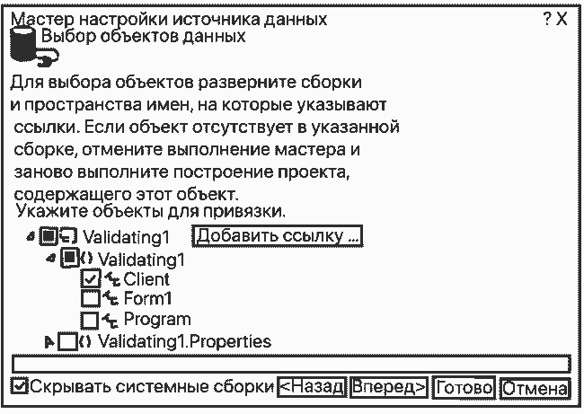

Рис. 2.2. Выборка класса для привязки

В результате этих действий в таблице `DataGridView` отобразятся столбцы с заголовками, совпадающими с именами свойств класса `Client` (см. рис. 2.3). Растянем таблицу, чтобы поместились все столбцы и добавим три кнопки с текстом «Добавить». «Изменить» и «Удалить». Эти кнопки нам потребуются позже.

Страница 16

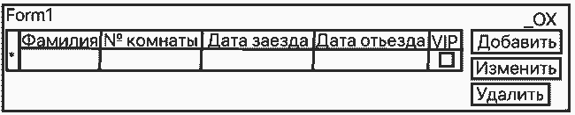

Рис. 2.3. Таблица после привязки к классу `Client`

**Примечание**. На рис. 2.3 изображены столбцы с отредактированными автором заголовками. Как это сделать, рассмотрим позже. **На панели компонентов** появится связыватель `BindingSource` под именем `clientBindingSource`. Во вторую часть класса `Form1` (файл `Form1.Designer.cs`) будет добавлена следующая строка: `clientBindingSource.DataSource = typeof(Client);`. **Привязка, которую мы выполнили**, является первым уровнем привязки, предназначенным только для создания столбцов. Для того чтобы появились данные, необходимо выполнить привязку к реальному списку клиентов, который мы пока не создали. Этот список мы создадим позже. Привязка будет осуществляться на этапе выполнения программы. **Сложная привязка** элементов управления к источникам данных подробно рассмотрена в первом томе учебника. Сейчас же поговорим об особенностях привязки `DataGridView` к источнику данных с помощью посредника `BindingSource`. **Среда разработки** автоматически добавляет столбцы только для открытых простых свойств. Открытые поля игнорируются. Позже столбцы можно будет отредактировать: удалить, переста. вить, изменить заголовки и т.д. Отображение открытых сложных свойств, например списков или массивов, не осуществляется. Столбцы типа `ComboBox`, как правило, имеют дополнительную привязку к своим источникам данных.

Страница 17

### Продолжим разработку проекта.

Создадим обработчик `Form1_Load`, вставим в него код для создания списка клиентов и выполним привязку связывателя (`clientBinding Source`) к этому списку:

```
List<Client> list = new List<Client>();
private void Form1_Load(object sender, EventArgs e)
{
    list.Add(
        new Client(
            "Иванов"
            , 101
            , new DateTime(2018, 04,22)
            , new DateTime(2018, 05, 22)
            , false
        )
    );
```

```
    list.Add(
        new Client(
            "Николаев"
            , 103
            , new DateTime(2018, 05,12)
            , new DateTime(2018, 07, 22)
            , false
        )
    );
    list.Add(
        new Client(
            "Сидоров"
            , 201
            , new DateTime(2018, 06, 15)
            , new DateTime(2018, 06, 30)
            , false
        )
    );
```

[output not shown]

[output not shown]

Собором решение и запустим пробрамму на выполнение. Получим окно, представленнос на рис. 2.4.

Страница 18

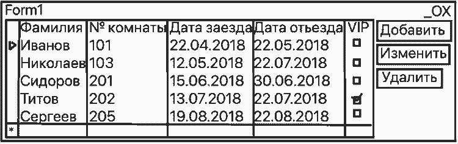

Рис. 2.4. Окно программы с таблицей клиситов

Каждая строка таблицы соответствует объекту источника данных. Строки таблицы с точки зрения теории структур данных называются записями.

# 2.3. Настройка таблицы в визуальном режиме

Используя визуальные средства, выполним настройку таблицы, полученной в разделе 2.2. Настройку таблицы можно выполнять на уровне свойств таблицы и на уровне свойств столбцов. В первом случае будут заданы глобальные настройки, действующие для всех объектов таблицы по умолчанию. Если необходимо индивидуальные настройки выполнить для отдельного столбца, то следует перейти к свойствам столбца.

Страница 19

# ОТОБРАЖАЕМЫЕ СВОЙСТВА ТАБЛИЦЫ

В окне свойств таблицы отображается около 70 свойств. Опиать все эти свойства в одном разделе учебника не представляется возможным, поэтому рассмотрим наиболее значимые свойства.

**Anchor** - возвращает или задает границы контейнера (формы), с которым связана таблица, и определяет способ изменения размеров таблицы при изменении размеров его родительского элемента (формы). Свойство получает комбинацию значений перечисления `AnchorStyles`. Если таблица должна быть привязана только к правой границе формы, то следует установить: `dataGridView1.Anchor = AnchorStyles. Right;`. В этом случае при перемещении правой границы формы с помощью мыши, также будет перемещаться и таблица, сохраняя расстояние до правой границы формы неизменным. Если же таблицу дополнительно привязать и к левой границе: `dataGridView1.Anchor = AnchorStyles.Left | AnchorStyles. Right;` то при изменении ширины формы расстояние как слева, так и справа от таблицы до вертикальных границ формы будет оставаться неизменным, благодаря чему таблица также будет либо растягиваться, либо сужаться. Растягивая таблицу, можно показать столбцы, оставшиеся за пределами отображаемой части. Такая установка свойства `Anchor` позволяет отказаться от горизонтальной полосы прокрутки таблицы.

Страница 20

Дня кнопки button2, находяшейся под таблицей, можно установить `button1.Anchor = AnchorStyles.Bottom | AnchorStyles.Left`

**AutoSizeColumnsMode** - возрашает или задает значение, указываясе, как по умолчаник, определяется ширина каждого столбца таблицы. Если ширина всех или многих столбцов таблицы должна определяться одним и тем же способом, то лучше этог способ определить в свойстве таблицы `AutoSizeColumnsMode`. Позже для конкретных столбцов можно изменить заданное по умолчанию) значение, воспользовавшись их свойством `DataGridViewColumn.AutoSizeMode`.

Свойство `AutoSizeColumnsMode` имеет значение типа `DataGridViewAutoSizeColumnsMode`, которое является перечислением и определясь следующие члены:

- **None** - ширина столбнов актоматически не изменяется.
- **AllCell** - ширина столбцов изменяется так, чтобы вместипь содержимос всех яческ столбцов (отображаемых и неотображаемых), включая ячейки заголовков.
- **AllCellsExceptHeader** - ширина столбцов изменяется так, что бы вместиль содержимое всех яческ столбцов, за исклюочением яческ заголовков.
- **DisplayedCellis** - ширина столбцов изменяется так, чтобы вместить, содержимое всех ячеек столбцов, которые находятся в строках, отображаюшихся на экране в настоящий момент, включая ячейки заголовков. Недостаком данного способа является то, что ширина каждого столбца вычисляется только на основе видимой части таблицы в момент ее первого отображения. Это означает, что, ссли в результате вертикальной прокрутки таблицы встретится ячейка с более длинным содержимым, то оно будет усечено, а к видимой части содержимого будут добавлены три точки. Однако как только пользователь перейдет в режим заполнения этой ячейки, ширина столбца изменится в соответствии с введенным значением.
- **DisplayedCellsExceptHeader** — ширина столбцов изменяется так, чтобы вместить содержимое всех ячеек столбцов, которые находятся в строках, отображающихся на экране в настоящий момент, исключая ячейки заголовков. Данный режим имеет те же недостатки, что и `DisplayedCells`.
- **ColumnHeader** - ширина столбцов изменяется так, чтобы вместить содержимое ячеек заголовков столбцов.
- **Fill** — ширина столбцов подбирается таким образом, чтобы суммарная ширина всех столбцов в точности заполняла отображаемую область элемента управления, а прокрутка по горизонтали требовалась только для того, чтобы не допускать уменьшения ширины столбцов ниже значений свойства `DataGridViewColumn.MinimumWidth`, которое по умолчанию равно 5. Относительная ширина столбцов определяется значениями свойства `DataGridViewColumn.FillWeight`.

Страница 21

1. Автоматическое изменсние размеров на основе содержимого запрещает пользователям изменять значения ширины столбцов с помощью мыши во время выполнения программы. Пользователь может уменьшить или увеличить ширину столбца, для которого определено значение None или Fill, наведя курсор на правую гранищу ячейки заголовка и протащив эту границу в гребуемую сторону при нажатой левой кланише мыши. **Дополнительные сведения** о способах определения ширины стоябна приведены ниже, при описании свойств столбца (ем. «Настройка ширины конкретного столбца»).

**Рекомендации 1**. Если в ячейках столбцов таблицы могут стречаться как короткие, так и длинные строки, то рекомендуется установить свойство `AutoSizeColumnsMode` таблицы в значение `AllCells`. При этом ширина каждого столбца будет установлена по самому длинному значению его ячеек, что гарантирует отображение длинных строк целиком. Правда, при этом правые столбцы могут выйти за границу таблицы, вследствие чего появится горизонтальная полоса прокрутки. Альтернативой значения `AllCells` является значение None и установка для всех столбцов или конкретного столбца с длинными значениями стиля `WrapMode=true` (см. рис. 2.5), в результате чего будет выполняться перенос слов содержимого на следующую строку ячейки.

Страница 22

2. Если столбцы не помещаются целиком в отображаемую часть таблицы, и Вы не хотите использовать полосу прокрутки, можно воспользоваться свойством `Anchor` таблицы.
- **AutoSizeRowsMode** — возвращает или задает значение, казывающее, как определяется высота строки. Это свойство позволяст наспраивать элемент управления таким образом, что при изменении содержимого ячейки высота строки будет корректироваться автоматически. **Если свойство** `DataGridViewCellStyle.WrapMode` включено, высота строки также корректирустся при изменении ширины сколоца. Свойство имест тип `DataGridViewAutoSizeRowsMode`. Ниже представлены константы этого перечисления: **Во первых**, None; **Во вторых**, AllGells; **В третьих**, AllcellsExceptHeaders;
- **AllHeaders** - значения высоты строк изменяются в соответствии с содержимым заголовков строк: **Во первых**, DisplayedCells; **Во первых**, DisplayedCellsExceptHeaders;
- **DisplayedHeaders** - значения высоты строк изменяются в соответствии с содержимым заголовков строк, отображасмых в текущий момент на экране.
- **AllowDrop** - возвращает или задает значение, указывающее, может ли элемент управления принимать данные, перетаскиваемые в него пользователем.

Страница 23

- **AllowUserToAddRows** - вознращаст или задаст значение, указывающее, отображается ли для пользователя в конце таблицы строка для добавления нового объекта (записи).
- **AllowUserToDeleteRows** - возвращает или задает значение, указывающее, разрешено ли пользователю удалять строки из объекта `DataGridView` с помощью клавиши `Delete`.
- **AllowUserToOrderColumns** — возвращаст или задаст значение. указывающее, может ли пользователь изменять мышью положение столбца.
- **AllowUserToResizeColumns** - возвращает или задаст значение, указывающее, может ли пользователь изменять мышью ширину столбцов.
- **AllowUserToResizeRows** - возвращает или задает значение, указывающее, может ли пользоватсль изменять мышью высоту строк.
- **ReadOnly** - возвращает или задает значение, указывающее, может ли пользователь изменять значения ячеек элемента управлония `DataGridView`.
- **CellBorderStyle** - получаст стиль границы ячейки для обьекта `DataGridView`. Возможные значения: **во первых**, Custom - праница, которая была настросна; **во вторых**, Single - одинарная граница; **в третьих**, Raised - грехмерная выпуклая граница; **в четвертых**, Sunken - трехмерная утопленная граница; **в пятых**, None — отсукствие границ;
- **SingleVertical** — вертикальная одинарная граница;
- **RaisedVertical** — вертикальная трехмерная выпуклая граница;
- **SingleHorizontal** - горизонтальная одинарная граница;
- **RaisedHorizontal** — горизонтальная трехмерная выпукла граница;
- **SunkenHorizontal** — горизонтальная трехмерная утопленная граница.
- **DefaultCellStyle** - возвращаст или задаст стиль, который будет применяться по умолчанию ко всем ячейкам таблицы

Страница 24

Страница 25

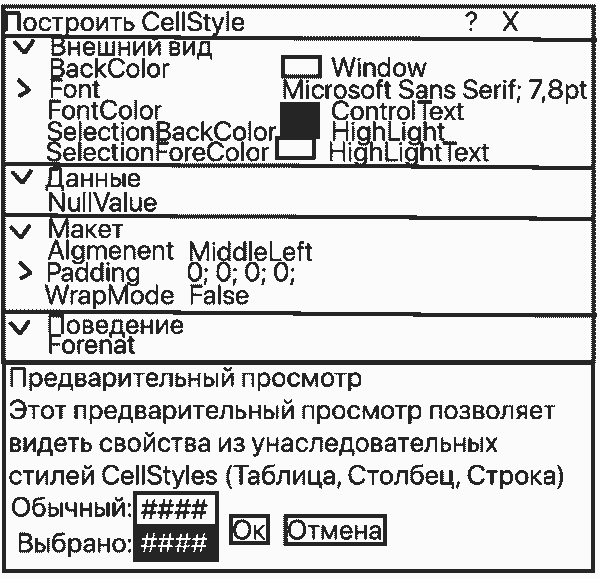

Рис. 2.5. Окно свойств стиля ячеек таблицы

**ColumnHeadersDefaultCellStyle** - возвращает или задает стиль заголовков столбцов по умолчанию (см. рис, 2.5). Если для свойства `EnableHeadersVisualStyles` задано значение true, то стили группы «Внешний вид», установленные для заголовков столбцов игнорируются. Обратите внимание: по умолчанию для свойства `EnableHeadersVisualStyles` установлено значение `true`.

**ColumnHeadersHeight** - возвращает или задает высоту возвращает или (в пикселях) строки заголовков столбцов.

Страница 26

**ColumnHeadersHeightSizeMode** - возвращает или заласт значенис. указывающее, может ли корректироваться высота заголовков столбцов. а также может ли она корректироваться автоматически или же пользователем по содержимому заголовков. Возможные значения свойства задаются персчислением `DataGridView ColumnHeadersHeightSizeMode`, имеющим следующие константы:

- **AutoSize** — высота заголовка столбца настраивается, чтобы она соответствовала содержимому всех ячсек заголовков столбцов (значение по умолчанию).
- **EnableResizing** - пользователи могут настраивать высоту заголовка столбца с помощью мыши.
- **DisableResizing** - пользователи не могут изменить высоту заголовка столбца с помощью мыши.
- **ColumnHeadersVisible** - возвращает или задает значение, указывающее, отображается ли строка заголовков столбцов. Если Вы, например, отображаете числовую матрицу, то строка заголовков, скорее всего, будет не нужна.
- **RowsDefaultCellStyle** - возвращает или задает стиль по умолчанию, применяемый к ячейкам строк таблицы (см. рис. 2.5).
- **AlternatingRowsDefaultCellStyle** - возвращаст или задает по умолчанию стиль ячеек, применяемый к нечетным строкам таблицы (см. рис. 2.5)).
- **RowHeadersDefaultCellStyle** — возвращает или задает спить по умолчанию, применяемый к ячейкам заголовков строк (см. рис. 2.5)). Если для свойства `EnableHeadersVisualStyles` задано значение `true`, то стили группы «Внешний вид», установленные яля заголовков строк, игнорируются. Обратите внимание: по умолчанию для свойства `EnableHeadersVisualStyles` установлено значение `true`.
- **RowHeadersWidth** - возвращает или задает ширину (в пикселях) столбца, солержашего заголовки строк.

Страница 27

- **RowHeadersWidthSizeMode** - возвращает или задает значение, укавывающее, может ли корректироваться ширина заголовков строк, а также может ли она корреквироваться пользователем или же корректироваться автоматически при изменении ширины заголовков строк. Возможные значения (перечисление `DataGrшdViewRowHeadersWidthSizeMode`):
- **EnableResizing** - пользователи могут изменять ширину заголовка столбца с помощью мыши. Это значение исполь дется по умолчанню.
- **DisableResizing** - пользователи не могут изменять ширину заголовка столбца с помощью мыши.
- **AutoSizeToAllHeaders** — ширина заголовка строки изменяется, чтобы вместить содержимое всех яческ заголовка строки.
- **AutoSizeToDisplayedHeaders** - ширина заголовка строки изменяется, чтобы вместить содержимое всех отображенных яческ заголовка строки.
- **AutoSizeToFirstHeader** - ширина заголовка строки изменяется, чтобы вместить содержимое первого заголовка строки.

Когда для свойства `RowHeadersWidthSizeMode` задан режим автоматического изменения размера, ширина заголовков строк не может корректироваться пользователем.

Осталось еще несколько свойств, отображаемых в окне «Свойства», но не перечнеленных выше. Многне свойства, относящиеся к одной и той же области использования, разбросаны по разным категориям. Объединим их.

Страница 28